# WorkshopDNADNA

```python
# general lib for data exploration
import numpy as np
import pandas as pd
import matplotlib.pyplot as plt
#import seaborn as sns
import torch
# To have images inline in the notebook without saving them
%matplotlib inline

# general python lib
import os
import datetime
import time

# to reload our modules if modified
from importlib import reload

import dnadna.prediction as pred
import dnadna.nets as nets
import dnadna.datasets as dat
from dnadna.snp_sample import SNPSample
from torch.utils.data import DataLoader
from torch import nn
```

```python
!dnadna --version
```

```
1.0.0rc2.dev2+g7d8f198
```

Follow https://github.com/EvoGenomicsAI/Workshop/blob/main/dnadna_notes_onthefly.md

to check for additionnal info on the fly during the tutorial (such as debugging etc)

# Inferring demography using an end-to-end deep learning approach, using `dnadna`

We are given a dataset of simulations of **bacteria** with variable population size. Bacteria have (for most of them) a **single and circular chromosome**. They are haploid.

In some of the simulations, there is a mutation that provides a **selective** advantage to the individual, meaning that this bacteria will have on average more offsprings per generation. If the size of the population is constant, the frequency of this mutation will increase, and may reach fixation (present in 100% of the population) or not. This mutation was added in the middle of the simulated chromosome. In reality, there is no middle since the chromosome is circular.

The goal of this session is to build a **neural network** that is able to infer the size of the population through time. This is a **regression** task.

We can infer either the time and strength of the change in population size, or infer the size at different time steps.

# Parameters used for the simulations

Simulations were performed using SLiM, a forward in time simulator. Populations go through a bottleneck or an immediate expansion whose timing and amplitude are drawn randomly. In some of the simulations, there is a SNP under selection, where again, the time of apparition and the strength of selection are randomly drawn. At the end of the simulation, 600 individuals (or haplotypes) are drawn.

Genome are 2 Mb long, mutation rate and recombination rate are also dranw randomly.

```python
DATAPATH = "DataWorkshop_DNADNA/"
```

```python
# Reducing artificially the number of replicate to 5
n_rep = 5
df_param = pd.read_table(DATAPATH + "SPIBact_param_1000_original", index_col=0)
df_param.n_replicates = n_rep
df_param.to_csv(DATAPATH + "SPIBact_param_1000", sep='\t')
```

```python
df_all_param = pd.read_csv("Simulations_all_params.csv", index_col=0)
df_all_param.n_replicates = n_rep
```

```python
df_all_param.head()
```

| scenario_idx | mu | geneconv_ratio | len_conv | chr_size | Ne | N_generations | T_bottleneck | strength_bottleneck | coeff_sel | Tstart_sweep | selection | model_init | n_replicates |
| --- | --- | --- | --- | --- | --- | --- | --- | --- | --- | --- | --- | --- | --- |
| 1 | 5.750000e-10 | 0.215443 | 122000.0 | 2065000.0 | 117090.909091 | 21900.0 | 4689.655172 | 0.274194 | NaN | NaN | False | BottleneckNoselection-015 | 5 |
| 8 | 1.168750e-09 | 0.011860 | 122000.0 | 2065000.0 | 105636.363636 | 21900.0 | 13206.896552 | 0.535484 | NaN | NaN | False | BottleneckNoselection-015 | 5 |
| 15 | 1.593750e-10 | 0.153174 | 122000.0 | 2065000.0 | 132710.743802 | 21900.0 | 2448.275862 | 0.912903 | NaN | NaN | False | BottleneckNoselection-015 | 5 |
| 18 | 1.584375e-09 | 0.065285 | 122000.0 | 2065000.0 | 41074.380165 | 21900.0 | 5137.931034 | 0.622581 | NaN | NaN | False | BottleneckNoselection-015 | 5 |
| 21 | 8.718750e-10 | 0.108902 | 122000.0 | 2065000.0 | 23371.900826 | 21900.0 | 5586.206897 | 0.419355 | NaN | NaN | False | BottleneckNoselection-015 | 5 |

```python
df_param.head()
```

| scenario_idx | T00 | T01 | T02 | T03 | T04 | T05 | T06 | T07 | T08 | T09 | ... | T12 | T13 | T14 | T15 | T16 | T17 | T18 | T19 | T20 | n_replicates |
| --- | --- | --- | --- | --- | --- | --- | --- | --- | --- | --- | --- | --- | --- | --- | --- | --- | --- | --- | --- | --- | --- |
| 1 | 117090.909091 | 117090.909091 | 117090.909091 | 117090.909091 | 117090.909091 | 32105.571848 | 32105.571848 | 32105.571848 | 32105.571848 | 32105.571848 | ... | 32105.571848 | 32105.571848 | 32105.571848 | 32105.571848 | 32105.571848 | 32105.571848 | 32105.571848 | 32105.571848 | 32105.571848 | 5 |
| 8 | 105636.363636 | 105636.363636 | 105636.363636 | 105636.363636 | 105636.363636 | 105636.363636 | 105636.363636 | 105636.363636 | 105636.363636 | 105636.363636 | ... | 105636.363636 | 56566.568915 | 56566.568915 | 56566.568915 | 56566.568915 | 56566.568915 | 56566.568915 | 56566.568915 | 56566.568915 | 5 |
| 15 | 132710.743802 | 132710.743802 | 132710.743802 | 121152.066116 | 121152.066116 | 121152.066116 | 121152.066116 | 121152.066116 | 121152.066116 | 121152.066116 | ... | 121152.066116 | 121152.066116 | 121152.066116 | 121152.066116 | 121152.066116 | 121152.066116 | 121152.066116 | 121152.066116 | 121152.066116 | 5 |
| 18 | 41074.380165 | 41074.380165 | 41074.380165 | 41074.380165 | 41074.380165 | 25572.114103 | 25572.114103 | 25572.114103 | 25572.114103 | 25572.114103 | ... | 25572.114103 | 25572.114103 | 25572.114103 | 25572.114103 | 25572.114103 | 25572.114103 | 25572.114103 | 25572.114103 | 25572.114103 | 5 |
| 21 | 23371.900826 | 23371.900826 | 23371.900826 | 23371.900826 | 23371.900826 | 23371.900826 | 9801.119701 | 9801.119701 | 9801.119701 | 9801.119701 | ... | 9801.119701 | 9801.119701 | 9801.119701 | 9801.119701 | 9801.119701 | 9801.119701 | 9801.119701 | 9801.119701 | 9801.119701 | 5 |

5 rows × 22 columns

We can see the change in population size for a random sample of scenario.

You can change the n_scenario value to see more of them.

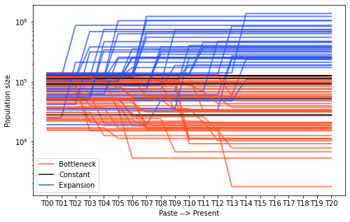

```python
n_scenario = 100
plt.figure(figsize=(8, 5))
for scenario in df_param.index[np.random.randint(0, len(df_param), n_scenario)]:
    if df_param.loc[scenario].T00 > df_param.loc[scenario].T20:
        color = "#FF5025"
        l = "Bottleneck"
    elif df_param.loc[scenario].T00 == df_param.loc[scenario].T20:
        color = "k"
        l = "Constant"
    else:
        color = "#2550FF"
        l = "Expansion"
    plt.plot(df_param.loc[scenario].filter(regex="T\w{2}"), c=color, lw=2, alpha=0.7, label=l)
plt.yscale("log")
plt.ylabel("Population size")
plt.xlabel("Paste --> Present")
handles = plt.gca().get_legend_handles_labels()
_, uniq_handle =  np.unique(handles[1], return_index=True)
plt.legend(np.array(handles[0])[uniq_handle], np.array(handles[1])[uniq_handle])
```

### What does a matrice of SNP look like ?

```python
snp_sample = SNPSample.from_file(DATAPATH + "/scenario_00001/BacterialDemoSelection_00001_000.npz")
```

```python
snp_sample.shape # individual/haplotype, number of snp
```

```
(600, 837)
```

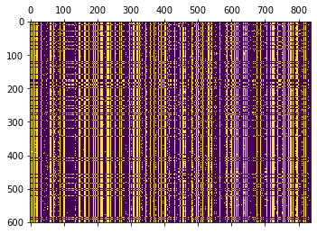

```python
plt.matshow(snp_sample.tensor, aspect="auto")
```

These matrices are input of the neural networks. For various reason, like constrain of the network, or for data augmentation, it might be handy to apply **transformations** on the SNP matrix.

`dnadna` [implements various](https://mlgenetics.gitlab.io/dnadna/_autosummary/dnadna.transforms.html) transformations :

```python
import dnadna.transforms as tr
```

```python
sub_sample = tr.Subsample(3,
                          keep_polymorphic_only=True)
sub_sample_keep_all = tr.Subsample(3,
                                  keep_polymorphic_only=False)
```

```python
new_sample = sub_sample((snp_sample, None, None)) # The 2 other parameters are not of interest here.
new_sample_keep_all = sub_sample_keep_all((snp_sample, None, None))
```

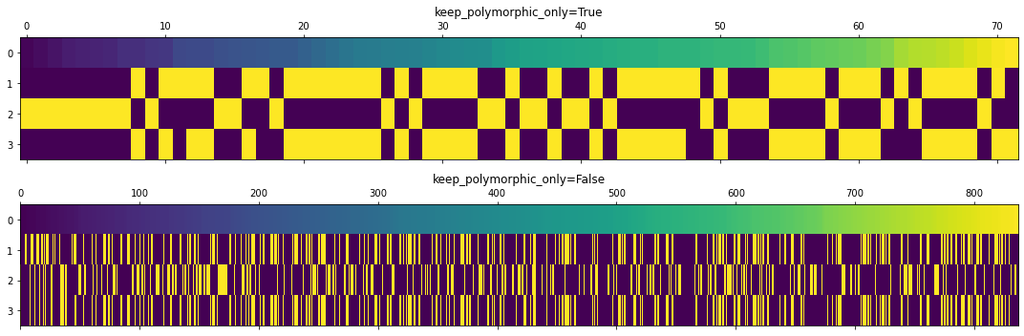

```python
fig, ax = plt.subplots(2, 1, figsize=(15, 5))
ax[0].matshow(new_sample[0].tensor, aspect="auto")
ax[0].set_title("keep_polymorphic_only=True")
ax[1].matshow(new_sample_keep_all[0].tensor, aspect="auto")
ax[1].set_title("keep_polymorphic_only=False")
plt.tight_layout()
```

**Can you comment the differences between the 2 figures above ?**

-->

The following command **crops** the matrix of SNP up to a given number of SNP and of individuals

```python
crop = tr.Crop(max_snp=15,
               max_indiv=10,
               keep_polymorphic_only=False)
```

```python
sample_crop = crop((snp_sample, None, None))
```

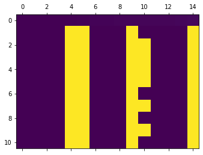

```python
plt.matshow(sample_crop[0].tensor, aspect="auto")
```

-->

```python
crop = tr.Crop(max_snp=15,
               max_indiv=10,
               keep_polymorphic_only=True)
```

```python
sample_crop = crop((snp_sample, None, None))
```

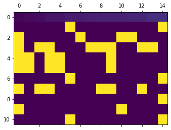

```python
plt.matshow(sample_crop[0].tensor, aspect="auto")
```

# Inferrence using `dnadna`

`dnadna` is a [software](https://hal.archives-ouvertes.fr/hal-03352910/document) whose aim is to help researcher develop and reuse deep learning methods for population genetics inferences.

It implements the four main steps to facilitate the development of this type methods.

- simulation
- preprocessing
- training
- prediction

We will use all of the steps except the simulation one, which is time-consuming, and not the core of `dnadna` since people usually have their simulations.

## `dnadna init` : setting up input data

In this case, we already have our simulation done. They are located under the `DATAPATH` variable we defined earlier.

We need to tell dnadna where is the data, and how they are formatted, if they are already simulated.

We create a `dataset_config` file to tell `dnadna` where is our data, and how it look likes.

- `data_root` is where the root directory of the dataset is
- `dataset_name` is the name of the directory of the dataset

Basically, your dataset will be structured like this:

```
data_root
     \__ scenario_001
         \__ replicate_1.npz
         ...
     \__ scenario_002
     ...
```

- `scenario_params_path`: The path to the table we saw above. It has to contain a column `scenario_idx`, a column `n_replicates` and as many columns as there are parameters to learn. There can be additional columns.
- `data_source`: Describes how the data is organized. The [format dnadna](https://mlgenetics.gitlab.io/dnadna/datasets.html#the-dnadna-dataset-format) assumes that each SNP matrix and associated positions array are stored together in a single NPZ file, either compressed or uncompressed, under the 'SNP' and 'POS' keys respectively.

```python
DATAPATH
```

```
'DataWorkshop_DNADNA/'
```

**If needed update the following cell to point to the correct datapath:**

```python
%%writefile dataset_config.yml
data_root: DataWorkshop_DNADNA
dataset_name: BacterialDemoSelection
scenario_params_path: DataWorkshop_DNADNA/SPIBact_param_1000
data_source:
    format: dnadna
    filename_format: "scenario_{scenario}/{dataset_name}_{scenario}_{replicate}.npz"
```

```
Overwriting dataset_config.yml
```

Initialize dnadna by telling it where the data are coming from (`--dataset-config`) and where we will store the deep learning models (`DLModel`)

```python
!dnadna init --dataset-config=dataset_config.yml DLModel
```

```
Writing sample preprocessing config to DLModel/DLModel_preprocessing_config.yml ...
Edit the dataset and/or preprocessing config files as needed, then run preprocessing with the command:

    dnadna preprocess DLModel/DLModel_preprocessing_config.yml
```

**Only if using jupyter-lab (not the case today!)** You can edit other file within jupyter lab in a another jupyter lab panel, so you can see the notebook and the config file side by side. Just drag it from the directory sidebar to where you want it.

[figure not shown]

## `dnadna preprocess` : preprocess input data

Sometimes we have constrains imposed by the network, and to prevent the training precedure from crashing, we discard some of the simulations because they have too little SNP or individuals.

During this step, we will also:

- split the dataset in training, validation and test (optional) sets
- tell `dnadna` which parameters we want to regress on. `dnadna` will then normalize the data (if we do a regression), so all predicted data are of the same order of magnitude and have a similar weight when computing the loss.
- Other transformations on these parameters can be applied, such as log-transformation if needed.

We edit the file created at the previous step (`DLModel/DLModel_preprocessing_config.yml`) to set how we want the preprocessing to occur.

Below is a snippet that will generate the section `learned_params` for the preprocessing config file. To run it, change the cell to `code` by typping `y` in control mode (other jupyter mode is edition, when you write within the cell).

Copy and paste the output in the corresponding section of the preprocessing config file. You can switch this cell back to 'raw' to remove the long output by typping `r`, or hide the cell by clicking on the vertical blue (or orange) bar.

```python
print("learned_params:")
for c in df_param.columns[:-1]:
    print(f"""    {c}:
        type: regression
        loss_func: MSE
        loss_weight: 1""")
```

```
learned_params:
    T00:
        type: regression
        loss_func: MSE
        loss_weight: 1
    T01:
        type: regression
        loss_func: MSE
        loss_weight: 1
    T02:
        type: regression
        loss_func: MSE
        loss_weight: 1
    T03:
        type: regression
        loss_func: MSE
        loss_weight: 1
    T04:
        type: regression
        loss_func: MSE
        loss_weight: 1
    T05:
        type: regression
        loss_func: MSE
        loss_weight: 1
    T06:
        type: regression
        loss_func: MSE
        loss_weight: 1
    T07:
        type: regression
        loss_func: MSE
        loss_weight: 1
    T08:
        type: regression
        loss_func: MSE
        loss_weight: 1
    T09:
        type: regression
        loss_func: MSE
```

[output cut: 30 more lines]

```
        type: regression
        loss_func: MSE
        loss_weight: 1
    T18:
        type: regression
        loss_func: MSE
        loss_weight: 1
    T19:
        type: regression
        loss_func: MSE
        loss_weight: 1
    T20:
        type: regression
        loss_func: MSE
        loss_weight: 1
```

Another section of the preprocessing, is to chose the proportion of your dataset that is going to be used for **training**, **validation** and **test** sets.

To have not too long training time, we recommand chosing:

```
dataset_splits:
    # portion of the dataset to use for training
    training: 0.1

    # portion of the dataset to use for validation
    validation: 0.01

    test: 0.01
```

**What are the different uses of these 3 sets ?**

Finally, we want to remove scenarios which have too few SNP (< 400). This is a constrain of some of the network we will use. We also want to keep simulations with at least 50 sampled individuals.

In the preprocessing config file, we thus have :

```
preprocessing:
    # minimum number of SNPs each sample should have
    min_snp: 400

    # minimum number of individuals in each sample
    min_indiv: 50
```

**If there are many cpus on your machine, you can use them for speeding up pre-processing**. With e.g. `n_worker: 4`

**Jupyter-lab tip: You can right-click on a cell and "Enable scrolling for Outputs", so very long output won't take all the space** Additionnaly, you can (left) click on the the vertical blue bar on the left of each cell to hide it.

Once the configuration file for **preprocessing** is filled and saved, we can start the preprocessing:

```python
!dnadna preprocess DLModel/DLModel_preprocessing_config.yml
```

[output not shown]

[output cut: 179 more lines]

**How many simulations will be used for training given that prepossessing might have filtered out some of the simulations ?**

```python
df_pre_param = pd.read_csv("DLModel/DLModel_preprocessed_params.csv", index_col=0)
```

```python
df_pre_param.head()
```

| scenario_idx | T00 | T01 | T02 | T03 | T04 | T05 | T06 | T07 | T08 | T09 | ... | T13 | T14 | T15 | T16 | T17 | T18 | T19 | T20 | n_replicates | splits |
| --- | --- | --- | --- | --- | --- | --- | --- | --- | --- | --- | --- | --- | --- | --- | --- | --- | --- | --- | --- | --- | --- |
| 132 | -0.379608 | -0.379608 | -0.375891 | -0.230561 | -0.501274 | -0.507598 | -0.467584 | -0.491524 | -0.513554 | -0.519812 | ... | -0.680786 | -0.724671 | -0.724671 | -0.724671 | -0.724671 | -0.724671 | -0.724671 | -0.724671 | 5 | training |
| 245 | -0.170202 | -0.170202 | -0.167276 | -0.167386 | -0.206178 | -0.212892 | -0.240289 | -0.314496 | -0.336339 | -0.478524 | ... | -0.648229 | -0.692245 | -0.692245 | -0.692245 | -0.692245 | -0.692245 | -0.692245 | -0.692245 | 5 | validation |
| 331 | 1.121983 | 1.121983 | 1.120029 | 0.222452 | 0.170369 | 0.163157 | 0.049744 | -0.401888 | -0.423823 | -0.434228 | ... | -0.613300 | -0.657457 | -0.657457 | -0.657457 | -0.657457 | -0.657457 | -0.657457 | -0.657457 | 5 | training |
| 497 | 0.240948 | 0.240948 | 0.242321 | -0.043347 | -0.086368 | -0.093240 | -0.518077 | -0.530851 | -0.552922 | -0.557361 | ... | -0.710395 | -0.754159 | -0.754159 | -0.754159 | -0.754159 | -0.754159 | -0.754159 | -0.754159 | 5 | training |
| 520 | -0.011871 | -0.011871 | -0.009543 | -0.119619 | -0.160040 | -0.166815 | -0.204751 | -0.286818 | -0.308632 | -0.324360 | ... | -0.664115 | -0.708066 | -0.708066 | -0.708066 | -0.708066 | -0.708066 | -0.708066 | -0.708066 | 5 | training |

5 rows × 23 columns

**Can you comment on the values of the preprocessed parameters table compared to the initial one ?**

```python
df_pre_param.splits.value_counts()
```

```
training      82
validation     9
test           6
Name: splits, dtype: int64
```

The actual datasets' size is the number of replicates (n_rep) x these printed values

```python
print('n_rep:',n_rep)
df_pre_param.splits.value_counts() * n_rep
```

```
n_rep: 5
```

```
training      410
validation     45
test           30
Name: splits, dtype: int64
```

The configuration file for the next step is written in `DLModel/DLModel_training_config.yml`

## `dnadna train` : Train your network !

Chose your hyperparemeters (in the config file), your architecture (pick a net among [those available](https://mlgenetics.gitlab.io/dnadna/_autosummary/dnadna.nets.html), or create your own as a [plugin](https://mlgenetics.gitlab.io/dnadna/extending.html#adding-a-network), and go ! And try again !

Available hyperparameters :

- The **network** itself : has the biggest influence.
  - **You can start by using the CustomCNN and then the SPIDNA implemented in dnadna. Later we will see how to create your own network**
  - `n_snp` and `n_indiv` are parameters that can be specified in the training config file under network->params. If not specified they are inferred automatically from a data sample.
- The **optimizer** : Adam is considered one of the best, but feel free to pick the one you want among those [available here.](https://pytorch.org/docs/stable/optim.html#algorithms)
  - parameters of the optimizer :
    - **learning rate** : represents somehow the speed at which the network learns. It can have important impact.
    - other parameters that depends on the optimizer you choose.
- **Batch size**: How many samples are fed to the network at once between optimization steps. Very large batches tend to overgeneralize (and may not fit onto GPU's memory)
- **n_epoch**: Number of time the entire dataset is fed to the network for training
- dataset **transformations**: you can decide to add some constrain or augmentation on your data.
  - crop: you can decide to crop your matrices up to a given number of snp or individual (haplotypes). If you don't crop, matrices have different size, which may not work given the network you chose. If matrices have different sizes, for computational reasons, they need to be padded with -1 to have them with the same dimensions.
  - subsample: you can decide to subsample randomly your matrice.
  - keep_polymorphic_sites: tells whether you want to remove sites that are not snp anymore, because you removed all the individuals with the derived allel by subsampling or cropping.
  - your own transformation as a plugin, as shown later.

The **evaluation interval** (in number of batches), tells when the validation should occur. Having too many evaluation steps increase the time of training, so it's better to have about 3 evaluations per epoch for this tutorial. In one epoch, there is $\frac{size\_training\_set}{batch\_size}$ steps. So dividing this by 3 gives you the interval to have 3 evaluations step per epoch.

```python
# Compute evaluation interval variable

# This value can be changed to what you wrote in your config file
batch_size = 8 # number of SNP matrices processed simultaneously

n_train = df_pre_param.splits.value_counts()["training"]
steps = 3 # number of evaluation you want to perform per epoch
print("Number of training step per epoch:", int(np.ceil( n_train*n_rep / batch_size)))
print("In your config file, set evaluation_interval to:", int( n_train*n_rep / batch_size / steps))
```

```
Number of training step per epoch: 52
In your config file, set evaluation_interval to: 17
```

**Try to answer the following questions;** - Which network design make sense ? - When running on enough data: does one has better performance (what expremiment(s) would be required to reply to this?) - Do you observe any impact if you modify hyperparameters ? Which ones ? Does it improve the performance or not ?

**Note about how to run various experiments.** The `DLModel/DLModel_training config.yml` is a pivot configuration file and can be overwritten each time you run an experiment. In this file, there is `run_name_format: run_{run_id}` which is going to be the name of the folder created each time we launch `dnadna train`. This folder contains everything needed to reproduce a given run. run_id will be a number, increasing with runs. To help you keep track of your different experiment, you can modify it with something like: e.g `run_name_format: run_MLP_lr0.001_bs256_{run_id}`, if you train with a MLP, a learning rate of 0.001 and a batch size of 256.

**Every cell that starts by `! something` are actually shell command, and can be executed in a terminal, that you can open within jupyter lab the **+** button in the upper left**. Doing so will allow you to execute other thing in the terminal while the network is training

**Before executing the next command line, here are tricks to make the training faster and less computationnally heavy when you do not have access to a GPU cluster. For the sake of the tutorial you will edit the training config file:** - Do NOT use all SNPs set crop param to `max_snp: 400` - Do NOT use all individuals set crop param to `max_indiv: 50` (you'll see another transform that you could use) - use GPUs whenever possible (not today) - increase `batch_size` as much as possible (i.e. so that it will still fit in the available memory), e.g. to 16, 32, 64 .. - decrease `n_epochs`, e.g. to 1 - reduce the number of evaluation steps (=validation steps) by increasing `evaluation_interval` see the cell for computing this number, a few step above

```python
!dnadna train DLModel/DLModel_training_config.yml
```

```
2022-06-13 23:21:04;     INFO;  Process ID: 26273
2022-06-13 23:21:04;     INFO;  Preparing training run
2022-06-13 23:21:04;     INFO;  Initializing dataset...
2022-06-13 23:21:04;     INFO;  45 samples in the validation set and 410 in the training set
2022-06-13 23:21:04;     INFO;  inferred parameters for CustomCNN: n_snp=400, n_indiv=50, concat=True
2022-06-13 23:21:04;     INFO;  Start training
2022-06-13 23:21:04;     INFO;  Networks states are saved after each validation step
2022-06-13 23:21:04;  WARNING;  Current behavior if SNP matrices have different shapes: padding with -1 (right and bottom) to fit the maximum dimension within each batch.

2022-06-13 23:21:04;     INFO;  Starting Epoch #1

2022-06-13 23:21:05;     INFO;  Validation at epoch: 1 and batch: 1

2022-06-13 23:21:05;     INFO;  Compute all outputs for validation dataset...


2022-06-13 23:21:07;     INFO;  Done

2022-06-13 23:21:07;     INFO;  training loss = 1.274923324584961 // validation loss = 0.3395397663116455

2022-06-13 23:21:07;     INFO;  Better loss found on validation set: None --> 0.3395397663116455

2022-06-13 23:21:07;     INFO;  Saving model to "/home/fjay/Documents/WORK/Teaching/PSL/tuto-PSL/WorkshopDNADNA/DLModel/run_000/DLModel_run_000_best_net.pth" ...

2022-06-13 23:21:20;     INFO;  Validation at epoch: 1 and batch: 18

2022-06-13 23:21:20;     INFO;  Compute all outputs for validation dataset...


2022-06-13 23:21:22;     INFO;  Done

2022-06-13 23:21:22;     INFO;  training loss = 0.9227120098140504 // validation loss = 0.41703441739082336

2022-06-13 23:21:35;     INFO;  Validation at epoch: 1 and batch: 35

2022-06-13 23:21:35;     INFO;  Compute all outputs for validation dataset...


2022-06-13 23:21:37;     INFO;  Done

```

[output cut: 13 more lines]

```

2022-06-13 23:21:54;     INFO;  Done

2022-06-13 23:21:54;     INFO;  --- 49.5445601940155 seconds ---
2022-06-13 23:21:54;     INFO;  --- Best loss: 0.3395397663116455
2022-06-13 23:21:54;     INFO;  Saving model to "/home/fjay/Documents/WORK/Teaching/PSL/tuto-PSL/WorkshopDNADNA/DLModel/run_000/DLModel_run_000_last_epoch_net.pth" ...
2022-06-13 23:21:54;     INFO;  If tensorboard is installed, you can keep track of all training and validation losses by running the command:
2022-06-13 23:21:54;     INFO;      tensorboard --logdir /home/fjay/Documents/WORK/Teaching/PSL/tuto-PSL/WorkshopDNADNA/DLModel &
2022-06-13 23:21:54;     INFO;
2022-06-13 23:21:54;     INFO;  or display the current run only:
2022-06-13 23:21:54;     INFO;      tensorboard --logdir /home/fjay/Documents/WORK/Teaching/PSL/tuto-PSL/WorkshopDNADNA/DLModel/run_000
2022-06-13 23:21:54;     INFO;
2022-06-13 23:21:54;     INFO;  You can test the model's predictions on a test dataset by running the command:
2022-06-13 23:21:54;     INFO;
2022-06-13 23:21:54;     INFO;      dnadna predict /home/fjay/Documents/WORK/Teaching/PSL/tuto-PSL/WorkshopDNADNA/DLModel/run_000/DLModel_run_000_best_net.pth <dataset config file or paths to .npz files>
```

**On jupyter-lab with addidional packages (not for today): You can open Tensorboard to follow the evolution of your loss** To open tensorboard, click on the big **+** sign in the upper left, and then chose Tensorboard

**You can use Tensorboard to follow the evolution of your loss** In a terminal type: `tensorboard --logdir DLModel --port 8899 --bind_all` or another port number that we will specify) Then connect to tensorboard by opening `http://ec2-XXXX.compute-1.amazonaws.com:8899` Where XXX is the same number used for opening the jupyter notebook

**What was the training and validation loss at the end of epoch 1 ? at the time of best performance ? Why are these losses different ? Which one do you expect to be larger and why ?**

Results are stored in the run folder (update run number to check a given run):

```python
!ls DLModel/run_000/
```

```
DLModel_run_000_best_net.pth
DLModel_run_000_final_config.yml
DLModel_run_000_last_checkpoint_net.pth
DLModel_run_000_last_epoch_net.pth
DLModel_run_000_preprocessed_params.csv
DLModel_run_000_training.log
tensorboard
```

You can always check again the log file afterwards, it contains information about training and validation losses:

```python
!cat DLModel/run_000/DLModel_run_000_training.log
```

```
2022-06-13 23:21:04;     INFO;  Process ID: 26273
2022-06-13 23:21:04;     INFO;  Preparing training run
2022-06-13 23:21:04;     INFO;  Initializing dataset...
2022-06-13 23:21:04;     INFO;  45 samples in the validation set and 410 in the training set
2022-06-13 23:21:04;     INFO;  inferred parameters for CustomCNN: n_snp=400, n_indiv=50, concat=True
2022-06-13 23:21:04;     INFO;  Start training
2022-06-13 23:21:04;     INFO;  Networks states are saved after each validation step
2022-06-13 23:21:04;  WARNING;  Current behavior if SNP matrices have different shapes: padding with -1 (right and bottom) to fit the maximum dimension within each batch.
2022-06-13 23:21:04;     INFO;  Starting Epoch #1
2022-06-13 23:21:05;     INFO;  Validation at epoch: 1 and batch: 1
2022-06-13 23:21:05;     INFO;  Compute all outputs for validation dataset...
2022-06-13 23:21:07;     INFO;  Done
2022-06-13 23:21:07;     INFO;  training loss = 1.274923324584961 // validation loss = 0.3395397663116455
2022-06-13 23:21:07;     INFO;  Better loss found on validation set: None --> 0.3395397663116455
2022-06-13 23:21:07;     INFO;  Saving model to "/home/fjay/Documents/WORK/Teaching/PSL/tuto-PSL/WorkshopDNADNA/DLModel/run_000/DLModel_run_000_best_net.pth" ...
2022-06-13 23:21:20;     INFO;  Validation at epoch: 1 and batch: 18
2022-06-13 23:21:20;     INFO;  Compute all outputs for validation dataset...
2022-06-13 23:21:22;     INFO;  Done
2022-06-13 23:21:22;     INFO;  training loss = 0.9227120098140504 // validation loss = 0.41703441739082336
2022-06-13 23:21:35;     INFO;  Validation at epoch: 1 and batch: 35
2022-06-13 23:21:35;     INFO;  Compute all outputs for validation dataset...
2022-06-13 23:21:37;     INFO;  Done
2022-06-13 23:21:37;     INFO;  training loss = 0.988203045300075 // validation loss = 0.4046587646007538
2022-06-13 23:21:50;     INFO;  Validation at epoch: 1 and batch: 52
2022-06-13 23:21:50;     INFO;  Compute all outputs for validation dataset...
2022-06-13 23:21:52;     INFO;  Done
2022-06-13 23:21:52;     INFO;  training loss = 1.0157207628855338 // validation loss = 0.49549025297164917
2022-06-13 23:21:52;     INFO;  Compute all outputs for validation dataset...
2022-06-13 23:21:54;     INFO;  Done
2022-06-13 23:21:54;     INFO;  --- 49.5445601940155 seconds ---
2022-06-13 23:21:54;     INFO;  --- Best loss: 0.3395397663116455
2022-06-13 23:21:54;     INFO;  Saving model to "/home/fjay/Documents/WORK/Teaching/PSL/tuto-PSL/WorkshopDNADNA/DLModel/run_000/DLModel_run_000_last_epoch_net.pth" ...
2022-06-13 23:21:54;     INFO;  If tensorboard is installed, you can keep track of all training and validation losses by running the command:
2022-06-13 23:21:54;     INFO;      tensorboard --logdir /home/fjay/Documents/WORK/Teaching/PSL/tuto-PSL/WorkshopDNADNA/DLModel &
2022-06-13 23:21:54;     INFO;
2022-06-13 23:21:54;     INFO;  or display the current run only:
2022-06-13 23:21:54;     INFO;      tensorboard --logdir /home/fjay/Documents/WORK/Teaching/PSL/tuto-PSL/WorkshopDNADNA/DLModel/run_000
2022-06-13 23:21:54;     INFO;
2022-06-13 23:21:54;     INFO;  You can test the model's predictions on a test dataset by running the command:
2022-06-13 23:21:54;     INFO;
2022-06-13 23:21:54;     INFO;      dnadna predict /home/fjay/Documents/WORK/Teaching/PSL/tuto-PSL/WorkshopDNADNA/DLModel/run_000/DLModel_run_000_best_net.pth <dataset config file or paths to .npz files>
```

## `dnadna predict` : Use an optimized network for prediction on a dataset

Prediction is done via a simple forward pass of the data through the fixed network (i.e. the weights are fixed and correspond to weights optimizing the performance during training)

Remark : If one wants to perform prediction on a dataset that did not go through preprocessing, and if the network or training had constrains on the minimum number of SNPs or individuals (such min_snp: 400) , using the option `--preprocess` will make sure that the same preprocessing is applied to the new simulations/datasets.

### Performing predictions with our trained network

We just trained a few networks. We will assess performance of the best network on a test set. Since we ask to create a test set during preprocessing, we can get the corresponding file names first and we give this file name to the predict sub-command.

The following cell get the filenames of the test set.

**Beware of the path !**

```python
%%bash
for scn in $(awk "-F", '$NF=="test"{printf "%05d\n", $1}' \
             DLModel/run_000/DLModel_run_000_preprocessed_params.csv); do
    for r in {000..005}; do  # change 005 to eg 099 to use all replicates
        echo  DataWorkshop_DNADNA/scenario_"$scn"/BacterialDemoSelection_"$scn"_"$r".npz
    done
done > test_files
```

```python
!wc -l test_files
```

```
36 test_files
```

```python
#modif

# !shuf -n 10 test_files > subset_test_files  # keep only a subset (for tutorial speed only)
!cp test_files subset_test_files # or keep all test sample
!wc -l subset_test_files
```

```
36 subset_test_files
```

```python
# Check what run was performed (some might have been aborted or not sucessful)
! ls -l DLModel/
```

```
total 328
-rw-rw-r-- 1 fjay fjay  42118 juin  13 23:18 DLModel_preprocessed_params.csv
-rw-rw-r-- 1 fjay fjay   3412 juin  13 23:18 DLModel_preprocessing_config.yml
-rw-rw-r-- 1 fjay fjay 184365 juin  13 23:18 DLModel_preprocessing.log
-rw-rw-r-- 1 fjay fjay   7293 juin  13 23:32 DLModel_training_config_duplicate.yml
-rw-rw-r-- 1 fjay fjay   7332 juin  14 01:01 DLModel_training_config.yml
drwxrwxr-x 3 fjay fjay   4096 juin  13 23:21 run_000
drwxrwxr-x 3 fjay fjay   4096 juin  13 23:38 run_001
drwxrwxr-x 2 fjay fjay   4096 juin  13 23:38 run_002
drwxrwxr-x 2 fjay fjay   4096 juin  13 23:39 run_003
drwxrwxr-x 2 fjay fjay   4096 juin  13 23:44 run_004
drwxrwxr-x 2 fjay fjay   4096 juin  13 23:45 run_005
drwxrwxr-x 3 fjay fjay   4096 juin  13 23:46 run_006
drwxrwxr-x 3 fjay fjay   4096 juin  13 23:47 run_007
drwxrwxr-x 3 fjay fjay   4096 juin  13 23:58 run_008
drwxrwxr-x 3 fjay fjay   4096 juin  14 00:00 run_009
drwxrwxr-x 3 fjay fjay   4096 juin  14 00:00 run_010
drwxrwxr-x 3 fjay fjay   4096 juin  14 00:01 run_011
drwxrwxr-x 3 fjay fjay   4096 juin  14 00:01 run_012
drwxrwxr-x 3 fjay fjay   4096 juin  14 00:03 run_013
drwxrwxr-x 3 fjay fjay   4096 juin  14 00:04 run_014
drwxrwxr-x 2 fjay fjay   4096 juin  14 00:06 run_015
drwxrwxr-x 3 fjay fjay   4096 juin  14 01:01 run_016
drwxrwxr-x 3 fjay fjay   4096 juin  14 01:02 run_017
drwxrwxr-x 3 fjay fjay   4096 juin  14 01:04 run_018
```

**Below is a temporary fix required before using dnadna predict.**

This will not be required in dnadna new version.

We apply manually the transformations necessary before prediction as they are not applied automatically for now. In particular respecting the input dimension is important, unless you trained a network that is invariant to input dimensions (both number of individuals and snps) and was exposed to various sizes while training (so that it would be robust to new dimensions never seen before)

```python
# Temporary fix, waiting for dnadna new version
# This will apply the mandatory transforms

def predict_after_transf(path_to_net, path_to_test_list, crop, colnames=df_param.columns[:-1]):

    p = pred.Predictor.from_net_file(path_to_net)

    test_predict=dict()
    with open(path_to_test_list) as files:
        for test_file in files.readlines():
            test_file = test_file.rstrip('\n')
            snp_sample = SNPSample.from_file(test_file)
            #print(test_file)
            x, _, _ = crop((snp_sample, None, None))
            if x.n_snp < crop.max_snp:
                print(f'skipping prediction for {test_file} (not enough snps after cropping individuals and keeping polymorphism sites only)')
                continue
            try:
                test_predict[test_file] = p.predict(x.tensor.type(torch.float)).to_scalars()
            except:
                print(f'Warning: skipping prediction for {test_file} of size:')
                print(snp_sample.n_snp, crop.max_snp)
                print(snp_sample.n_snp< crop.max_snp)
                print(x.shape)

    df = pd.DataFrame(test_predict).T
    if not colnames is None:
        df.columns = colnames
    df['path'] = df.index
    df["scenario_idx"] = df.path.str.split("/").apply(lambda x: int(x[-2].split("_")[1]))
    df.set_index("scenario_idx", inplace=True)
    return df
```

```python
# This transform corresponds to the operation applied to input before training:
crop = tr.Crop(max_snp=400,  #  n_snp the net was trained on
               max_indiv=50, #  n_indiv the net was trained on
               keep_polymorphic_only=True)
```

```python
run='000'
path_to_net=f"DLModel/run_{run}/DLModel_run_{run}_best_net.pth"
df_best = predict_after_transf(path_to_net=path_to_net, path_to_test_list="subset_test_files", crop=crop)
```

```
skipping prediction for DataWorkshop_DNADNA/scenario_08687/BacterialDemoSelection_08687_000.npz (not enough snps after cropping individuals and keeping polymorphism sites only)
skipping prediction for DataWorkshop_DNADNA/scenario_08687/BacterialDemoSelection_08687_001.npz (not enough snps after cropping individuals and keeping polymorphism sites only)
skipping prediction for DataWorkshop_DNADNA/scenario_08687/BacterialDemoSelection_08687_002.npz (not enough snps after cropping individuals and keeping polymorphism sites only)
skipping prediction for DataWorkshop_DNADNA/scenario_08687/BacterialDemoSelection_08687_003.npz (not enough snps after cropping individuals and keeping polymorphism sites only)
skipping prediction for DataWorkshop_DNADNA/scenario_08687/BacterialDemoSelection_08687_004.npz (not enough snps after cropping individuals and keeping polymorphism sites only)
skipping prediction for DataWorkshop_DNADNA/scenario_08687/BacterialDemoSelection_08687_005.npz (not enough snps after cropping individuals and keeping polymorphism sites only)
```

```python
df_best.head()
```

| scenario_idx | T00 | T01 | T02 | T03 | T04 | T05 | T06 | T07 | T08 | T09 | ... | T12 | T13 | T14 | T15 | T16 | T17 | T18 | T19 | T20 | path |
| --- | --- | --- | --- | --- | --- | --- | --- | --- | --- | --- | --- | --- | --- | --- | --- | --- | --- | --- | --- | --- | --- |
| 1304 | 78727.804688 | 80865.695312 | 80994.570312 | 102448.765625 | 92654.265625 | 102461.296875 | 88719.328125 | 162496.28125 | 122815.367188 | 121082.820312 | ... | 189381.250000 | 225587.625000 | 209602.343750 | 278175.06250 | 221246.828125 | 271858.25000 | 269227.28125 | 278125.00000 | 255698.890625 | DataWorkshop_DNADNA/scenario_01304/BacterialDe... |
| 1304 | 78733.593750 | 80872.101562 | 80997.437500 | 102431.953125 | 92693.812500 | 102437.507812 | 88706.562500 | 162545.25000 | 122795.546875 | 121052.023438 | ... | 189357.046875 | 225553.953125 | 209508.468750 | 278147.96875 | 221181.671875 | 271898.00000 | 269246.53125 | 278086.12500 | 255658.265625 | DataWorkshop_DNADNA/scenario_01304/BacterialDe... |
| 1304 | 78725.703125 | 80861.210938 | 80999.867188 | 102451.828125 | 92687.882812 | 102446.367188 | 88744.250000 | 162484.46875 | 122860.031250 | 121117.250000 | ... | 189438.078125 | 225400.468750 | 209527.890625 | 278215.03125 | 221240.031250 | 271804.21875 | 269052.90625 | 278098.93750 | 255733.406250 | DataWorkshop_DNADNA/scenario_01304/BacterialDe... |
| 1304 | 78723.476562 | 80872.757812 | 80996.609375 | 102465.476562 | 92670.281250 | 102469.960938 | 88678.375000 | 162457.03125 | 122800.945312 | 121095.859375 | ... | 189342.609375 | 225561.812500 | 209538.156250 | 278143.81250 | 221156.562500 | 271827.12500 | 269277.46875 | 278133.18750 | 255721.125000 | DataWorkshop_DNADNA/scenario_01304/BacterialDe... |
| 1304 | 78732.140625 | 80868.851562 | 80990.859375 | 102461.328125 | 92669.835938 | 102467.804688 | 88730.445312 | 162505.46875 | 122735.671875 | 121061.703125 | ... | 189363.968750 | 225496.046875 | 209526.687500 | 278172.46875 | 221176.421875 | 271874.56250 | 269093.59375 | 278120.90625 | 255665.187500 | DataWorkshop_DNADNA/scenario_01304/BacterialDe... |

5 rows × 22 columns